# Return Home

Download dataset

# Data Exploration & Cleaning

The first part of any data analysis or predictive modeling task is an initial exploration of the data. Even if you collected the data yourself and you already have a list of questions in mind that you want to answer, it is important to explore the data before doing any serious analysis, since oddities in the data can cause bugs and muddle your results. Before exploring deeper questions, you have to answer many simpler ones about the form and quality of data. That said, it is important to go into your initial data exploration with a big picture question in mind since the goal of your analysis should inform how you prepare the data.

```python
# Load in some packages
import calendar
import pandas as pd
import matplotlib.pyplot as plt
import warnings
warnings.filterwarnings("ignore")

# load dataset
ad_sales_df =pd.read_csv(r"C:\Users\jki\Downloads\3  Aldi Sales Datasets\Cleaned data\supermarket_sales.csv")
ad_sales_df.head(6)
```

|  | Invoice ID | Branch | City | Customer type | Gender | Product line | Unit price | Quantity | Tax 5% | Total | Date | Time | Payment | cogs | gross margin percentage | gross income | Rating |
| --- | --- | --- | --- | --- | --- | --- | --- | --- | --- | --- | --- | --- | --- | --- | --- | --- | --- |
| 0 | 750-67-8428 | A | Yangon | Member | Female | Health and beauty | 74.69 | 7 | 26.14 | 549 | 1/5/2019 | 1:08:00 PM | Ewallet | 522.83 | 4.76 | 26.14 | 9.1 |
| 1 | 226-31-3081 | C | Naypyitaw | Normal | Female | Electronic accessories | 15.28 | 5 | 3.82 | 80 | 3/8/2019 | 10:29:00 AM | Cash | 76.40 | 4.76 | 3.82 | 9.6 |
| 2 | 631-41-3108 | A | Yangon | Normal | Male | Home and lifestyle | 46.33 | 7 | 16.22 | 341 | 3/3/2019 | 1:23:00 PM | Credit card | 324.31 | 4.76 | 16.22 | 7.4 |
| 3 | 123-19-1176 | A | Yangon | Member | Male | Health and beauty | 58.22 | 8 | 23.29 | 489 | 1/27/2019 | 8:33:00 PM | Ewallet | 465.76 | 4.76 | 23.29 | 8.4 |
| 4 | 373-73-7910 | A | Yangon | Normal | Male | Sports and travel | 86.31 | 7 | 30.21 | 634 | 2/8/2019 | 10:37:00 AM | Ewallet | 604.17 | 4.76 | 30.21 | 5.3 |
| 5 | 699-14-3026 | C | Naypyitaw | Normal | Male | Electronic accessories | 85.39 | 7 | 29.89 | 628 | 3/25/2019 | 6:30:00 PM | Ewallet | 597.73 | 4.76 | 29.89 | 4.1 |

After getting a sense of the data's structure, it is a good idea to look at a statistical summary of the variables with df.describe()

```python
ad_sales_df.describe()
```

[output not shown]

```python
# lets  check for missing values
missing_values  = ad_sales_df.isna().sum()
print(missing_values)
```

```
Invoice ID                 0
Branch                     0
City                       0
Customer type              0
Gender                     0
Product line               0
 Unit price                0
Quantity                   0
 Tax 5%                    0
Total                      0
Date                       0
Time                       0
Payment                    0
cogs                       0
gross margin percentage    0
gross income               0
Rating                     0
dtype: int64
```

```python
# lets check the data types
ad_sales_df.info()
```

```
<class 'pandas.core.frame.DataFrame'>
RangeIndex: 1000 entries, 0 to 999
Data columns (total 17 columns):
 #   Column                   Non-Null Count  Dtype
---  ------                   --------------  -----
 0   Invoice ID               1000 non-null   object
 1   Branch                   1000 non-null   object
 2   City                     1000 non-null   object
 3   Customer type            1000 non-null   object
 4   Gender                   1000 non-null   object
 5   Product line             1000 non-null   object
 6    Unit price              1000 non-null   float64
 7   Quantity                 1000 non-null   int64
 8    Tax 5%                  1000 non-null   float64
 9   Total                    1000 non-null   int64
 10  Date                     1000 non-null   object
 11  Time                     1000 non-null   object
 12  Payment                  1000 non-null   object
 13  cogs                     1000 non-null   float64
 14  gross margin percentage  1000 non-null   float64
 15  gross income             1000 non-null   float64
 16  Rating                   1000 non-null   float64
dtypes: float64(6), int64(2), object(9)
memory usage: 132.9+ KB
```

```python
ad_sales_df['Date'] = pd.to_datetime(ad_sales_df['Date'])
ad_sales_df.info()
```

```
<class 'pandas.core.frame.DataFrame'>
RangeIndex: 1000 entries, 0 to 999
Data columns (total 17 columns):
 #   Column                   Non-Null Count  Dtype
---  ------                   --------------  -----
 0   Invoice ID               1000 non-null   object
 1   Branch                   1000 non-null   object
 2   City                     1000 non-null   object
 3   Customer type            1000 non-null   object
 4   Gender                   1000 non-null   object
 5   Product line             1000 non-null   object
 6    Unit price              1000 non-null   float64
 7   Quantity                 1000 non-null   int64
 8    Tax 5%                  1000 non-null   float64
 9   Total                    1000 non-null   int64
 10  Date                     1000 non-null   datetime64[ns]
 11  Time                     1000 non-null   object
 12  Payment                  1000 non-null   object
 13  cogs                     1000 non-null   float64
 14  gross margin percentage  1000 non-null   float64
 15  gross income             1000 non-null   float64
 16  Rating                   1000 non-null   float64
dtypes: datetime64[ns](1), float64(6), int64(2), object(8)
memory usage: 132.9+ KB
```

```python
# Creating a new variable can be as simple as taking one variable and adding, multiplying or dividing by another. Let's create a new variable, Month, from 'Order Date':



ad_sales_df['Month'] = ad_sales_df['Date'].dt.month
ad_sales_df['Month'].describe()
```

```
count    1000.000000
mean        1.993000
std         0.835254
min         1.000000
25%         1.000000
50%         2.000000
75%         3.000000
max         3.000000
Name: Month, dtype: float64
```

```python
ad_sales_df.head(5)
```

|  | Invoice ID | Branch | City | Customer type | Gender | Product line | Unit price | Quantity | Tax 5% | Total | Date | Time | Payment | cogs | gross margin percentage | gross income | Rating | Month |
| --- | --- | --- | --- | --- | --- | --- | --- | --- | --- | --- | --- | --- | --- | --- | --- | --- | --- | --- |
| 0 | 750-67-8428 | A | Yangon | Member | Female | Health and beauty | 74.69 | 7 | 26.14 | 549 | 2019-01-05 | 1:08:00 PM | Ewallet | 522.83 | 4.76 | 26.14 | 9.1 | 1 |
| 1 | 226-31-3081 | C | Naypyitaw | Normal | Female | Electronic accessories | 15.28 | 5 | 3.82 | 80 | 2019-03-08 | 10:29:00 AM | Cash | 76.40 | 4.76 | 3.82 | 9.6 | 3 |
| 2 | 631-41-3108 | A | Yangon | Normal | Male | Home and lifestyle | 46.33 | 7 | 16.22 | 341 | 2019-03-03 | 1:23:00 PM | Credit card | 324.31 | 4.76 | 16.22 | 7.4 | 3 |
| 3 | 123-19-1176 | A | Yangon | Member | Male | Health and beauty | 58.22 | 8 | 23.29 | 489 | 2019-01-27 | 8:33:00 PM | Ewallet | 465.76 | 4.76 | 23.29 | 8.4 | 1 |
| 4 | 373-73-7910 | A | Yangon | Normal | Male | Sports and travel | 86.31 | 7 | 30.21 | 634 | 2019-02-08 | 10:37:00 AM | Ewallet | 604.17 | 4.76 | 30.21 | 5.3 | 2 |

```python
ad_sales_df['Year'] = ad_sales_df['Date'].dt.year
ad_sales_df['Year'].describe()
```

```
count    1000.0
mean     2019.0
std         0.0
min      2019.0
25%      2019.0
50%      2019.0
75%      2019.0
max      2019.0
Name: Year, dtype: float64
```

```python
ad_sales_df
```

|  | Invoice ID | Branch | City | Customer type | Gender | Product line | Unit price | Quantity | Tax 5% | Total | Date | Time | Payment | cogs | gross margin percentage | gross income | Rating | Month | Year |
| --- | --- | --- | --- | --- | --- | --- | --- | --- | --- | --- | --- | --- | --- | --- | --- | --- | --- | --- | --- |
| 0 | 750-67-8428 | A | Yangon | Member | Female | Health and beauty | 74.69 | 7 | 26.14 | 549 | 2019-01-05 | 1:08:00 PM | Ewallet | 522.83 | 4.76 | 26.14 | 9.1 | 1 | 2019 |
| 1 | 226-31-3081 | C | Naypyitaw | Normal | Female | Electronic accessories | 15.28 | 5 | 3.82 | 80 | 2019-03-08 | 10:29:00 AM | Cash | 76.40 | 4.76 | 3.82 | 9.6 | 3 | 2019 |
| 2 | 631-41-3108 | A | Yangon | Normal | Male | Home and lifestyle | 46.33 | 7 | 16.22 | 341 | 2019-03-03 | 1:23:00 PM | Credit card | 324.31 | 4.76 | 16.22 | 7.4 | 3 | 2019 |
| 3 | 123-19-1176 | A | Yangon | Member | Male | Health and beauty | 58.22 | 8 | 23.29 | 489 | 2019-01-27 | 8:33:00 PM | Ewallet | 465.76 | 4.76 | 23.29 | 8.4 | 1 | 2019 |
| 4 | 373-73-7910 | A | Yangon | Normal | Male | Sports and travel | 86.31 | 7 | 30.21 | 634 | 2019-02-08 | 10:37:00 AM | Ewallet | 604.17 | 4.76 | 30.21 | 5.3 | 2 | 2019 |
| ... | ... | ... | ... | ... | ... | ... | ... | ... | ... | ... | ... | ... | ... | ... | ... | ... | ... | ... | ... |
| 995 | 233-67-5758 | C | Naypyitaw | Normal | Male | Health and beauty | 40.35 | 1 | 2.02 | 42 | 2019-01-29 | 1:46:00 PM | Ewallet | 40.35 | 4.76 | 2.02 | 6.2 | 1 | 2019 |
| 996 | 303-96-2227 | B | Mandalay | Normal | Female | Home and lifestyle | 97.38 | 10 | 48.69 | 1022 | 2019-03-02 | 5:16:00 PM | Ewallet | 973.80 | 4.76 | 48.69 | 4.4 | 3 | 2019 |
| 997 | 727-02-1313 | A | Yangon | Member | Male | Food and beverages | 31.84 | 1 | 1.59 | 33 | 2019-02-09 | 1:22:00 PM | Cash | 31.84 | 4.76 | 1.59 | 7.7 | 2 | 2019 |
| 998 | 347-56-2442 | A | Yangon | Normal | Male | Home and lifestyle | 65.82 | 1 | 3.29 | 69 | 2019-02-22 | 3:33:00 PM | Cash | 65.82 | 4.76 | 3.29 | 4.1 | 2 | 2019 |
| 999 | 849-09-3807 | A | Yangon | Member | Female | Fashion accessories | 88.34 | 7 | 30.92 | 649 | 2019-02-18 | 1:28:00 PM | Cash | 618.38 | 4.76 | 30.92 | 6.6 | 2 | 2019 |

1000 rows × 19 columns

## 1. What was the best month for sales? How much was earned that month?

```python
# Load in some packages
import calendar
import warnings
import pandas as pd
import matplotlib.pyplot as plt
from itertools import combinations
from collections import Counter

warnings.filterwarnings("ignore")

# 1. What was the best month for sales? How much was earned that month?

# Replace NaN or inf values in the 'Month' column with a default value (e.g., 0)
ad_sales_df['Month'] = ad_sales_df['Month'].fillna(0).astype(int)

# Convert month numbers to abbreviated month names
ad_sales_df['Month Name'] = ad_sales_df['Month'].apply(lambda x: calendar.month_abbr[x])

# Group by month and calculate total sales for each month
sales_by_month = ad_sales_df.groupby('Month Name').sum()['gross income']

# Find the best month for sales and the corresponding earnings
best_month = sales_by_month.idxmax()
earnings_for_best_month = sales_by_month.max()

print(f"The best month for sales was {best_month} with earnings of ${earnings_for_best_month:,.2f}")
```

```
The best month for sales was Jan with earnings of $5,537.95
```

```python
unique_Months = ad_sales_df['Month'].apply(lambda x: calendar.month_abbr[x]).unique() # Take all 12 months' names
Sales_by_month = ad_sales_df.groupby('Month').sum()['gross income'] # Take the highest number of sales for each month
```

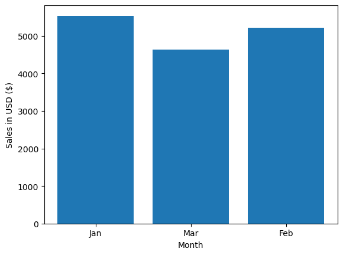

```python
# Plot the highest number of sales for each month
plt.bar(unique_Months, Sales_by_month)
plt.xticks(unique_Months)
plt.ylabel('Sales in USD ($)')
plt.xlabel('Month')
plt.show()
```

## 2. Which City had the highest number of sales?

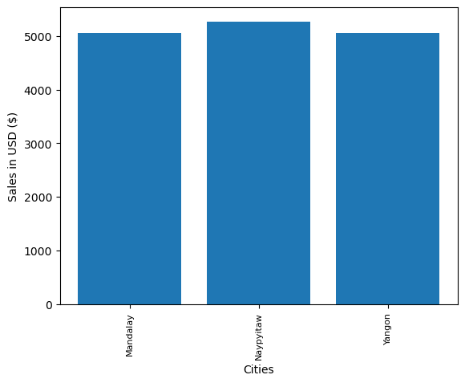

```python
# Plot the highest number of sales for each city

Sales_by_city = ad_sales_df.groupby('City').sum()['gross income'] # Take the number of sales for each city
unique_Cities = ad_sales_df.groupby('City').sum().index # Take all cities

# Plot the highest number of sales for each city
plt.bar(unique_Cities, Sales_by_city)
plt.xticks(unique_Cities, rotation = 90, size = 8)
plt.ylabel('Sales in USD ($)')
plt.xlabel('Cities')
plt.show()
```

## 3 Plot the highest number of sales for each customer type

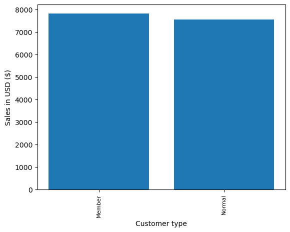

```python
# Plot the highest number of sales for each cusomer type

Sales_by_city = ad_sales_df.groupby('Customer type').sum()['gross income'] # Take the number of sales for each city
unique_Cities = ad_sales_df.groupby('Customer type').sum().index # Take all cities

# Plot the highest number of sales for each city
plt.bar(unique_Cities, Sales_by_city)
plt.xticks(unique_Cities, rotation = 90, size = 8)
plt.ylabel('Sales in USD ($)')
plt.xlabel('Customer type')
plt.show()
```

## 4 Plot the highest number of sales for each Gender

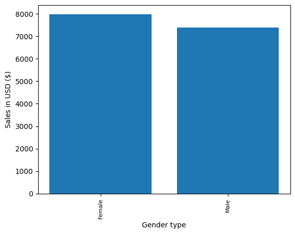

```python
# Plot the highest number of sales for each Gender type

Sales_by_city = ad_sales_df.groupby('Gender').sum()['gross income'] # Take the number of sales for each city
unique_Cities = ad_sales_df.groupby('Gender').sum().index # Take all cities

# Plot the highest number of sales for each Gender
plt.bar(unique_Cities, Sales_by_city)
plt.xticks(unique_Cities, rotation = 90, size = 8)
plt.ylabel('Sales in USD ($)')
plt.xlabel('Gender type')
plt.show()
```

## 5 Which Product Line had the highest number of sales?

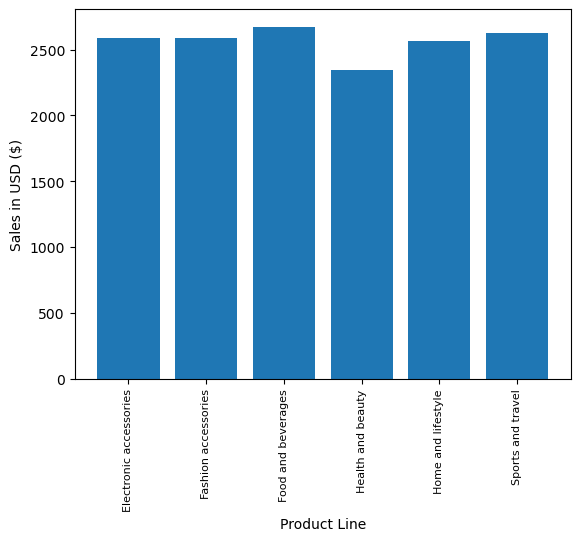

```python
# Plot the highest number of sales for each Product Line type

Sales_by_city = ad_sales_df.groupby('Product line').sum()['gross income'] # Take the number of sales for each city
unique_Cities = ad_sales_df.groupby('Product line').sum().index # Take all cities

# Plot the highest number of sales for each Product Line
plt.bar(unique_Cities, Sales_by_city)
plt.xticks(unique_Cities, rotation = 90, size = 8)
plt.ylabel('Sales in USD ($)')
plt.xlabel('Product Line')
plt.show()
```

## 6 Which Payment Type had the highest number of sales?

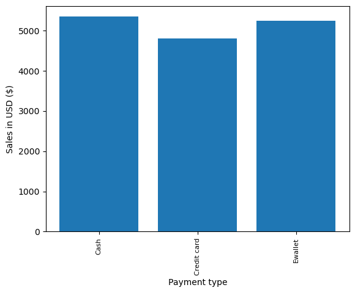

```python
# Which Payment had the highest number of sales?

# Plot the highest number of sales for each Payment  type

Sales_by_city = ad_sales_df.groupby('Payment').sum()['gross income'] # Take the number of sales for each city
unique_Cities = ad_sales_df.groupby('Payment').sum().index # Take all cities

# Plot the highest number of sales for each Payment  type
plt.bar(unique_Cities, Sales_by_city)
plt.xticks(unique_Cities, rotation = 90, size = 8)
plt.ylabel('Sales in USD ($)')
plt.xlabel('Payment type')
plt.show()
```

What product sold the most? Why do you think it sold the most?

In order to answer this question We just need to sum up the Quantity Ordered based on Grouped Products:

```python
unique_Products = ad_sales_df.groupby('Product line').sum().index
Quantity_Ordered_by_product = ad_sales_df.groupby('Product line').sum()['Quantity']
```

## 7 Let's see the product with the most quantity order with a bar graph:

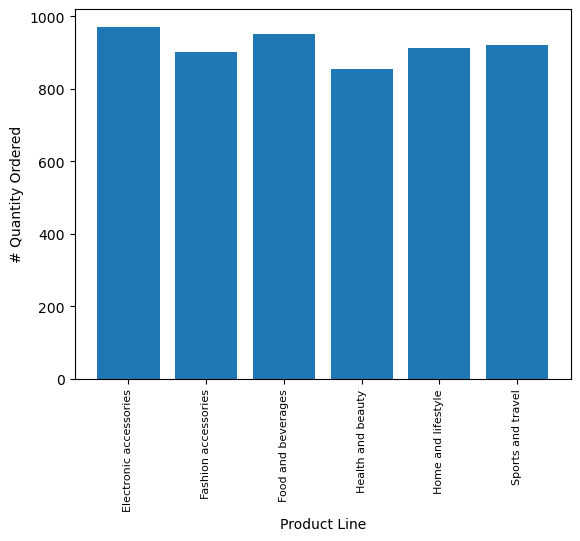

```python
# Plot the quantity ordered for each product
plt.bar(unique_Products, Quantity_Ordered_by_product)
plt.xticks(unique_Products, rotation = 90, size = 8)
plt.ylabel('# Quantity Ordered')
plt.xlabel('Product Line')
plt.show()
```